# Data Visualization Midterm: Take-Home Part 1

Complete this exam in a .Rmd file. To turn in the exam, push 4 .Rmd files and 4 knitted .html files to your GitHub repository.

Statement of Integrity: “All work presented is my own. I have not communicated with or worked with anyone else on this exam.” Jessica Tom

Collaboration Reminder: You may not communicate with or work with anyone else on this exam, but you may use any of our course materials or materials on the Internet.

Write a mini-tutorial for each of the following topics. You should use a data set that we did not use in class, quizzes, or exercises for each particular topic. But, you may use data sets we have used in class for other topics. For example, you may not use the tennis data set for a shiny mini-tutorial (since we used that data set in that section), but you could use the tennis data set for a tutorial on data visualization concepts (since we did not use that data set in that section).

There are a ton of data sets from STAT/DATA 234 in the /data folder that we have not used. Alternatively, you can find other data sets by Googling a topic followed by “github.”

# Mini-Tutorial 1: Data Visualization Concepts (20 points)

Topics to Cover:

Grammar of Graphics.

One topic from the Data Visualization Reading of your choice. - readings from section 3

A second topic from the Data Visualization Reading of your choice.

Make sure to include:

(4 points) An introductory statement with the goal of the section (in your own words) and a brief description of the data set and variables you will be using.

(16 points) R code chunks interspersed with some text descriptions about the code you have written and with text description about each topic. All three topics should have some R code. The data you use can be real data or it can be “toy” data (generated from tibble()).

you do not need to cover everything in these topics: aim for writing something that someone would be able to read through in ~ 10 minutes.

## Overview

In this section, the main goal is to focus on the the ways in which to create a data visualization, through the grammar of graphics, as well as some tips on how to make the data visualization an adequate representation of your data by utilizing human perception. To reach this goal, we will use the Pokemon data set, which has been filtered to specific types of Pokemon and contains variables such as:

- `Type` - the type of Pokemon (Bug, Electric, Fighting, Flying, Grass, and Steel)
- `Attack` - based on the Pokemon’s attack score
- `Defense` - based on the Pokemon’s defense score

```r
library(tidyverse)
pokemon_df <- read_csv("data/pokemon_full.csv")
```

```
## * `` -> ...1
```

```r
pokemon_filtered <- pokemon_df %>% filter(Type == "Bug" | Type == "Electric" | Type == "Fighting" | Type == "Flying" | Type == "Grass" | Type == "Steel")
```

## Grammar of Graphics

First, we will start off by explaining the grammar of graphics, which include the essential concepts of a graph. There are seven parameters or concepts of graphics:

- `<DATA>` - the data set
- `<MAPPINGS>` - the aesthetics of the graph, which go into aes()
- `<GEOM_FUNCTION>` - the type of graph
- `<STAT>` - statistical transformation
- `<POSITION>` - how the graph is formatted, or positioned
- `<FACET_FUNCTION>` - subplots for different data subsets
- `<COORDINATE_FUNCTION>` - the coordinate system chosen

You can adjust each of these parameters to create and individualize your graphic. For example, the following graph obviously uses the `<DATA>` component, signifying the graph to use the filtered Pokemon data set. It also uses `<MAPPINGS>` to specify what to put on the different axes. Lastly, `<GEOM_FUNCTION>` shows what type of graph to print (`geom_bar()` for a bar graph).

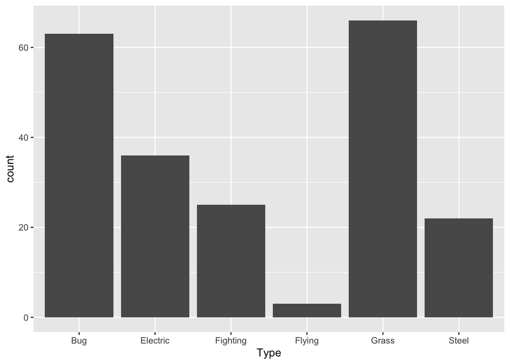

```r
ggplot(data = pokemon_filtered, aes(x = Type)) +
  geom_bar()
```

However, these components are adjustable, so you can change them in order to fit the data you want displayed. If, instead of the displaying the count of the different types, you wanted to explore `Attack` in relation to `Defense`, you can simply change mapping of the x and y variables in `aes()` and the geom function’s type of graph displayed, as shown below.

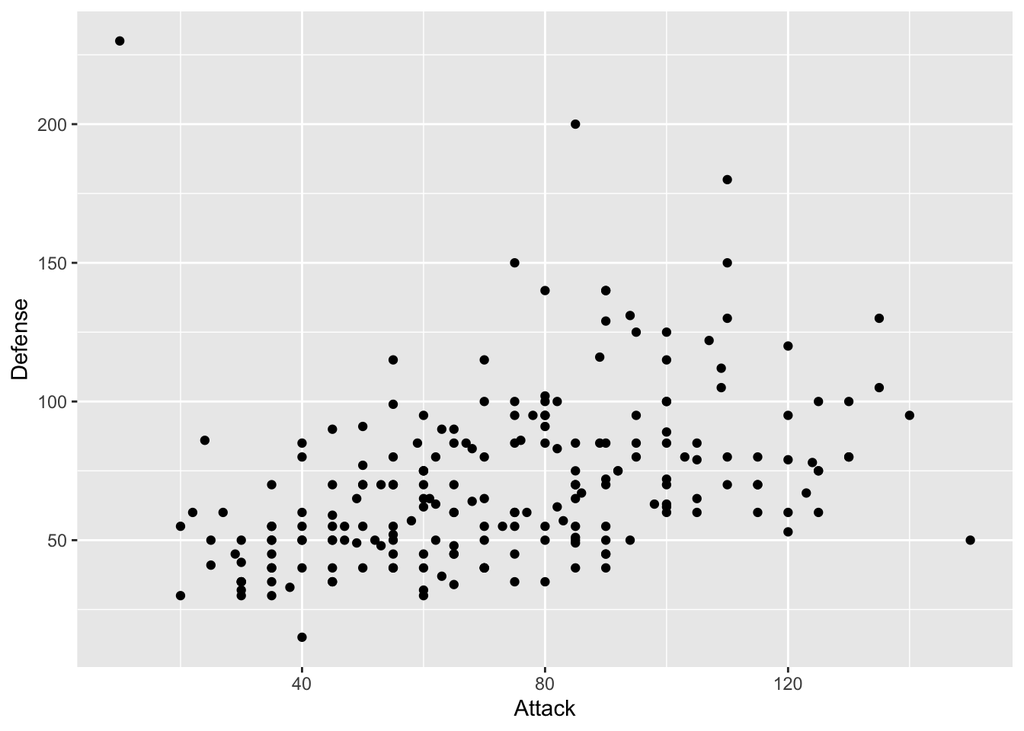

```r
ggplot(data = pokemon_filtered, aes(x = Attack, y = Defense)) +
  geom_point()
```

There are many other other ways to individualize your graphs, but here were just some ways to get you familiar with the grammar of graphics.

## Perception and Data Visualization

Not all graphs are created equal, but there are certain things you can do to make your graph more understandable for your audience. One way is through your color scheme. Because of the way humans perceive color scales, you want your color scheme to match the type of data you have. Thus, if you have a mid-point (like with temperature), you would want to use a diverging scale. However, if we wanted to group the points by `Type` for our Pokemon data set, as depicted below, we would want an unordered scheme because `Type` is an unordered categorical variable.

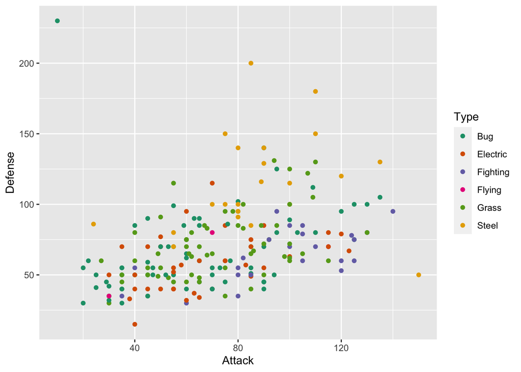

```r
ggplot(data = pokemon_filtered, aes(x = Attack, y = Defense, colour = Type)) +
  geom_point() +
  scale_color_brewer(palette = "Dark2")
```

Another tip is to use color to your advantage in order to emphasize certain points. For example, if we want to highlight Pikachu because we are interested in its observation, we could make Pikachu’s data point red, which stands out against the other black dots, drawing the viewer’s eyes in and creating less of a conscious search.

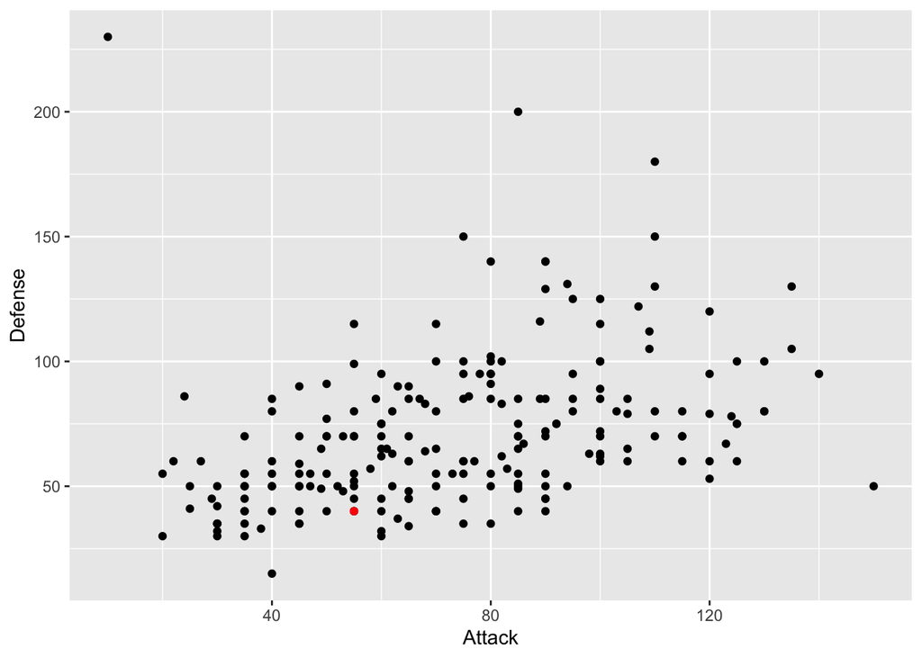

```r
pikachu <- pokemon_filtered %>% filter(Name == "Pikachu")
ggplot(data = pokemon_filtered, aes(x = Attack, y = Defense)) +
  geom_point() +
  geom_point(data = pikachu, colour = "red")
```

Submit your 4 tutorials as 4 separate .Rmd and .html files (for a total of 8 files) to your GitHub repository. Your commit and push of these files by Wednesday at 8:50 am makes up the final 5 points of the take-home exam.